# 25-VanLeigsen

Simon Schwab, Audrey Yeo

11/13/2019

# Reference

Van Leijsen et al. (2017). Plasma Aβ (Amyloid-β) Levels and Severity and Progression of Small Vessel Disease. *Stroke*, 16(5), 351–359. https://doi.org/10.1161/STROKEAHA.117.019810

We first load the appropriate packages

# Notes from reading methods section

- Dependant variable: AB38
- The independant variables
- ≥ 1 microbleeds (n = 81)
- no microbleed (n=405)
- ≥ 1 lacunes (n = 132)
- no lacunes (n = 355)
- Covariate: age

# Reading data

Data is loaded, reshaped if necessary, and factors are specified.

```
## 'data.frame':    487 obs. of  9 variables:
##  $ mb_presence_b : num  1 0 0 0 1 1 1 0 1 0 ...
##  $ lac_presence_b: num  1 1 1 1 1 1 1 1 1 0 ...
##  $ AB38          : num  23.7 29.7 26.7 33.5 16.6 38.4 27.1 31.8 24.4 30.1 ...
##  $ AB40          : num  224 225 195 243 131 ...
##  $ AB42          : num  55.8 63.6 63.9 62.3 57.4 72.1 64.8 62.7 60.2 64 ...
##  $ age           : num  73.8 69 74.3 64 71.7 ...
##  $ sex           : num  1 2 1 1 1 1 1 1 1 1 ...
##  $ hypertension  : num  1 1 1 1 1 1 1 1 0 1 ...
##  $ tbv_b         : num  955 1111 1069 1053 1025 ...
```

```
## [1] "lacunes"    "no lacunes"
```

# Descriptives

## DV with boxplot

Number of samples and mean (SD) in levels of the independant variables. We reproduce the mean and sd values of Table 2 of this study

```r
a = sprintf("%.1f (%.1f)", mean(data$AB38[data$mb_presence_b == 0]), sd(data$AB38[data$mb_presence_b == 0]))
b = sprintf("%.1f (%.1f)", mean(data$AB38[data$mb_presence_b == 1]), sd(data$AB38[data$mb_presence_b == 1]))

c = sprintf("%.1f (%.1f)", mean(data$AB38[data$lac_presence_b == 0]), sd(data$AB38[data$lac_presence_b == 0]))
d = sprintf("%.1f (%.1f)", mean(data$AB38[data$lac_presence_b == 1]), sd(data$AB38[data$mb_presence_b == 1]))

idx = c(1, 3, 2, 4) # sorting as in publication
tab.dv = array(NA, dim=c(4,3))
tab.dv[,1] = levels(data$Group.factor)
tab.dv[,2] = c("81", "405", "132", "355")
tab.dv[,3] = c(a, b, c, d)
colnames(tab.dv) = c("group", "n", "mean (SD)")
print(tab.dv)
```

```
##      group           n     mean (SD)
## [1,] "microbleed"    "81"  "23.2 (5.5)"
## [2,] "no microbleed" "405" "25.2 (6.1)"
## [3,] "lacunes"       "132" "23.1 (5.5)"
## [4,] "no lacunes"    "355" "24.7 (6.1)"
```

# boxplot with DV

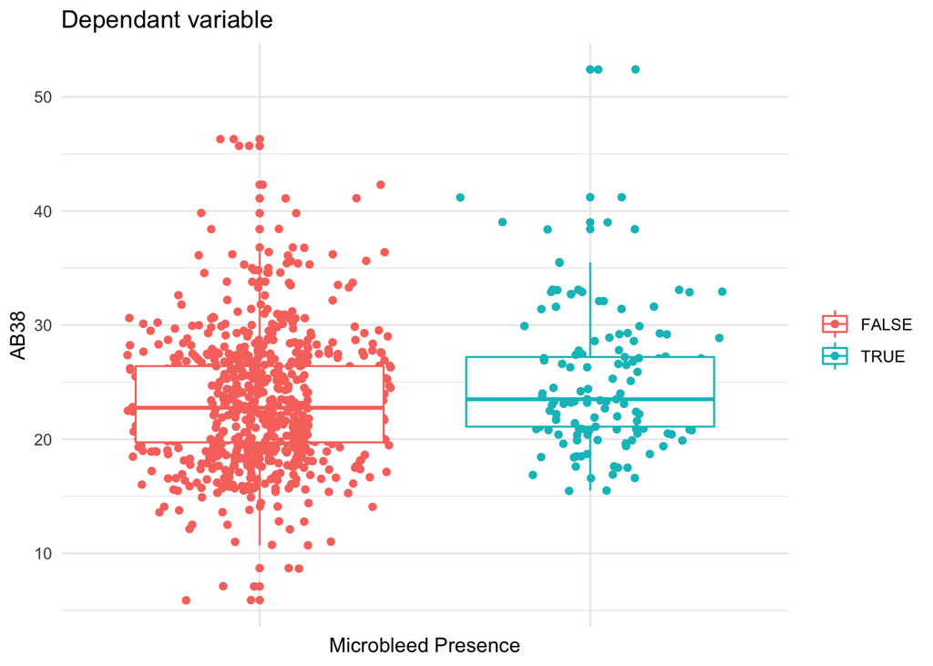

```r
#IV : mb_presence_b
ggplot(data, aes(y=AB38, x = mb_presence_b, color =mb_presence_b )) +
  geom_jitter() +
  geom_boxplot() +
  geom_point(position = position_jitter(width = 0.15, height = 0)) +
  theme_minimal() +
  theme(axis.text.x = element_blank(), legend.title = element_blank()) +
  xlab("Microbleed Presence") + ylab("AB38") + ggtitle("Dependant variable")
```

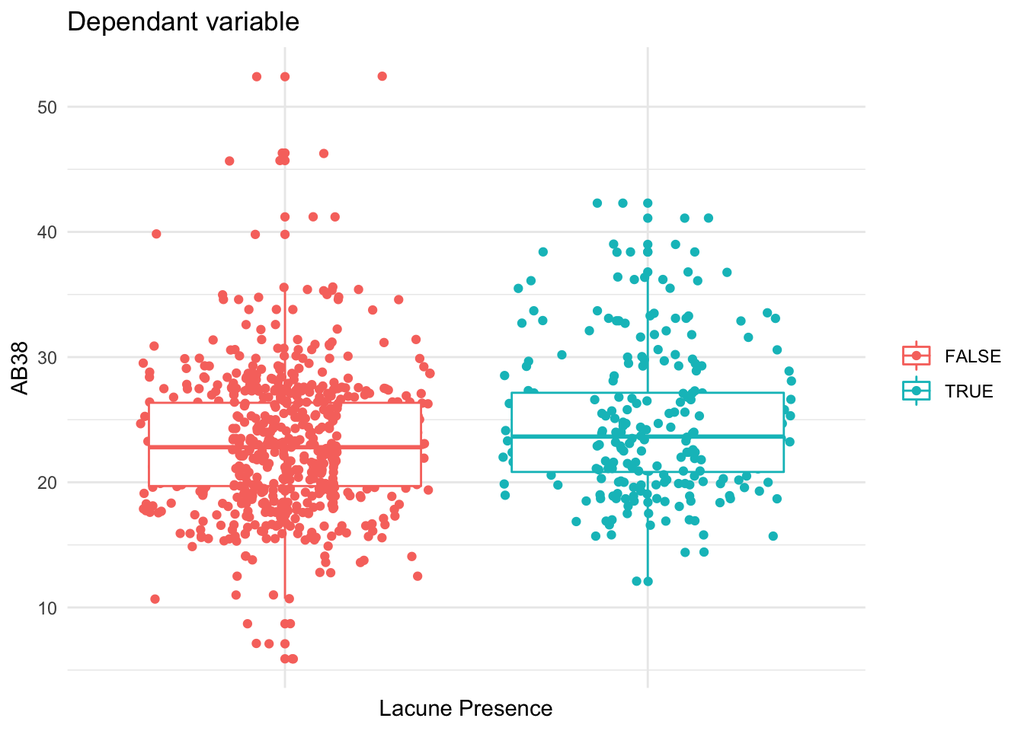

```r
#IV : lac_presence_b
ggplot(data, aes(y=AB38, x = lac_presence_b, color =lac_presence_b )) +
  geom_jitter() +
  geom_boxplot() +
  geom_point(position = position_jitter(width = 0.15, height = 0)) +
  theme_minimal() +
  theme(axis.text.x = element_blank(), legend.title = element_blank()) +
  xlab("Lacune Presence") + ylab("AB38") + ggtitle("Dependant variable")
```

# Descriptives

## COV with boxplot

```r
e = sprintf("%.1f (%.1f)", mean(data$age[data$mb_presence_b == 0]), sd(data$age[data$mb_presence_b == 0]))
f = sprintf("%.1f (%.1f)", mean(data$age[data$mb_presence_b == 1]), sd(data$age[data$mb_presence_b == 1]))
g = sprintf("%.1f (%.1f)", mean(data$age[data$lac_presence_b == 0]), sd(data$age[data$lac_presence_b == 0]))
h = sprintf("%.1f (%.1f)", mean(data$age[data$lac_presence_b == 1]), sd(data$age[data$mb_presence_b == 1]))

idx = c(1, 3, 2, 4) # sorting as in publication
tab.cv = array(NA, dim=c(4,3))
tab.cv[,1] = levels(data$Group.factor)
tab.cv[,2] = c("81", "405", "132", "355")
tab.cv[,3] = c(e,f,g,h)
colnames(tab.cv) = c("group", "n", "mean (SD)")
print(tab.cv)
```

```
##      group           n     mean (SD)
## [1,] "microbleed"    "81"  "64.9 (8.7)"
## [2,] "no microbleed" "405" "69.4 (8.1)"
## [3,] "lacunes"       "132" "64.4 (8.6)"
## [4,] "no lacunes"    "355" "69.0 (8.1)"
```

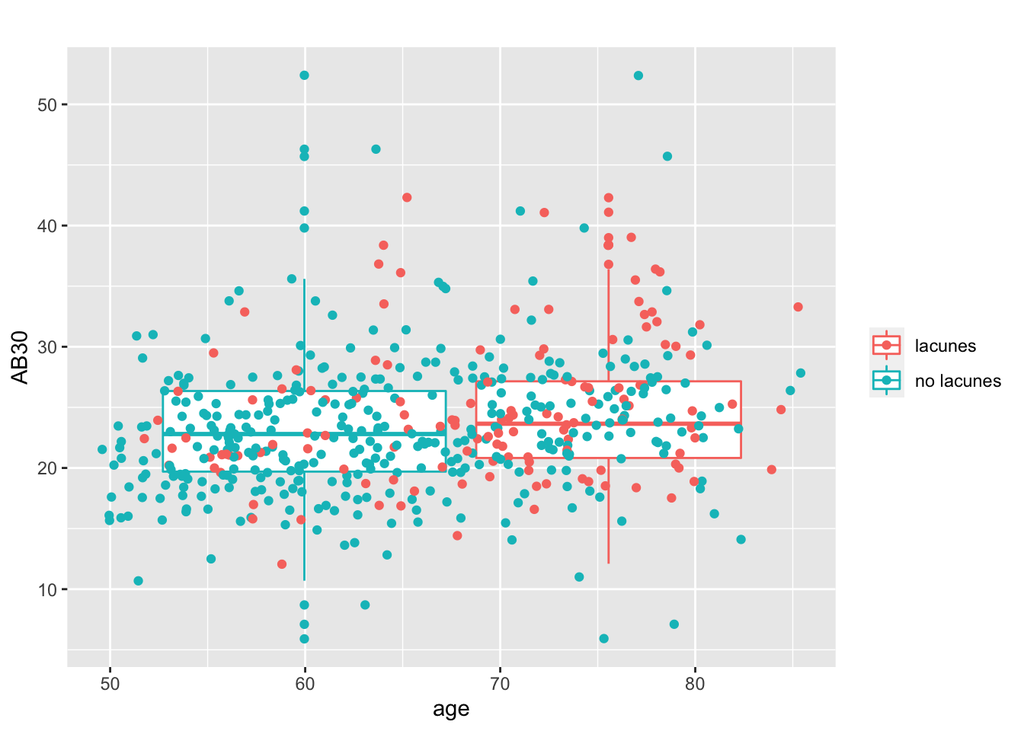

```r
ggplot(data,
       aes(y=AB38, x=age, color=Group.factor)) +
  geom_boxplot() +
  geom_jitter() +
  theme(legend.title = element_blank()) +
  labs(x = "age", y = "AB30", title = "" )
```

# Main analysis ANCOVA

We verify the p values stated in Table 2 with respect to variables.

```
##                 Df Sum Sq Mean Sq F value  Pr(>F)
## mb_presence_b    1    251   250.8   8.521 0.00367 **
## lac_presence_b   1    147   147.4   5.009 0.02568 *
## sex.factor       1      0     0.1   0.002 0.96074
## age              1    645   645.2  21.920 3.7e-06 ***
## hypertension     1    123   122.6   4.165 0.04180 *
## Residuals      481  14158    29.4
## ---
## Signif. codes:  0 '***' 0.001 '**' 0.01 '*' 0.05 '.' 0.1 ' ' 1
```

```
## Anova Table (Type III tests)
##
## Response: AB38
##                 Sum Sq  Df F value    Pr(>F)
## (Intercept)     1674.1   1 56.8760 2.334e-13 ***
## mb_presence_b     70.1   1  2.3803    0.1235
## lac_presence_b    31.9   1  1.0847    0.2982
## sex.factor         0.0   1  0.0001    0.9914
## age              465.7   1 15.8204 8.037e-05 ***
## hypertension     122.6   1  4.1653    0.0418 *
## Residuals      14157.7 481
## ---
## Signif. codes:  0 '***' 0.001 '**' 0.01 '*' 0.05 '.' 0.1 ' ' 1
```

```
## [1] 1
```

# Comparing ANCOVA in original study with reanalysis

## Independant variable

```
##         original Study reanalysis
## Fvalue  NA             "1.08"
## df1     NA             " 1"
## df2     NA             " 1"
## pvalue  "0.001"        "0.30"
## MD      NA             NA
## lowerCI NA             NA
## upperCI NA             NA
```

```
##         original Study reanalysis
## Fvalue  NA             "2.38"
## df1     NA             " 1"
## df2     NA             " 1"
## pvalue  NA             "0.12"
## MD      NA             NA
## lowerCI NA             NA
## upperCI NA             NA
```

# Assumptions

## 1. Homogeneity of variance

- ANOVA/ANCOVA is fairly robust in terms of the error rate when sample sizes are equal.
- When groups with larger sample sizes have larger variances than the groups with smaller sample sizes, the resulting F-ratio tends to be conservative. That is, it’s more likely to produce a non-significant result when a genuine difference does exist in the population.
- Conversely, when the groups with larger sample sizes have smaller variances than the groups with smaller samples sizes, the resulting F-ratio tends to be liberal and can inflate the false positive rate.

```
##    FALSE     TRUE
## 5.471873 6.069102
```

```
##    FALSE     TRUE
## 5.459909 5.870429
```

```
## Levene's Test for Homogeneity of Variance (center = median)
##        Df F value Pr(>F)
## group   1  1.3772 0.2412
##       485
```

```
## Levene's Test for Homogeneity of Variance (center = median)
##        Df F value Pr(>F)
## group   1  0.0912 0.7628
##       485
```

## 2. Independence between covariate and IV

The IV of this study have evidence of significant effect to the plasma level AB38.

```
##                 Df Sum Sq Mean Sq F value  Pr(>F)
## lac_presence_b   1    256  256.33   8.312 0.00411 **
## mb_presence_b    1    142  141.91   4.602 0.03243 *
## Residuals      484  14926   30.84
## ---
## Signif. codes:  0 '***' 0.001 '**' 0.01 '*' 0.05 '.' 0.1 ' ' 1
```

## 3. Homogeneity of regression slopes

```
## Anova Table (Type III tests)
##
## Response: AB38
##                    Sum Sq  Df F value    Pr(>F)
## (Intercept)        1525.8   1 51.5329 2.673e-12 ***
## age                 537.3   1 18.1457 2.461e-05 ***
## mb_presence_b        16.5   1  0.5560    0.4562
## age:mb_presence_b    28.4   1  0.9603    0.3276
## Residuals         14301.0 483
## ---
## Signif. codes:  0 '***' 0.001 '**' 0.01 '*' 0.05 '.' 0.1 ' ' 1
```

```
## Anova Table (Type III tests)
##
## Response: AB38
##                     Sum Sq  Df F value    Pr(>F)
## (Intercept)         1316.4   1 44.3402 7.524e-11 ***
## age                  464.9   1 15.6599 8.720e-05 ***
## lac_presence_b         4.1   1  0.1398    0.7087
## age:lac_presence_b    10.4   1  0.3490    0.5550
## Residuals          14340.2 483
## ---
## Signif. codes:  0 '***' 0.001 '**' 0.01 '*' 0.05 '.' 0.1 ' ' 1
```

## Independance of Covariate with Independant Variables

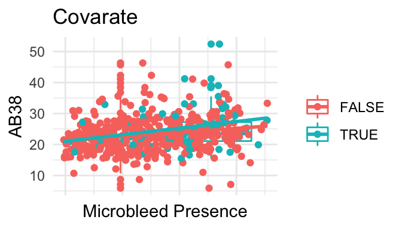

```r
ggplot(data, aes(y=AB38, x= age, color= mb_presence_b)) +
  geom_boxplot() +
  geom_point(position = position_jitter(width = 0.15, height = 0)) +
  geom_smooth(formula = y ~ x,method=lm, se=FALSE, fullrange=TRUE) +
  theme_minimal() +
  theme(axis.text.x = element_blank(), legend.title = element_blank()) +
  xlab("Microbleed Presence") + ylab("AB38") + ggtitle("Covarate")
```

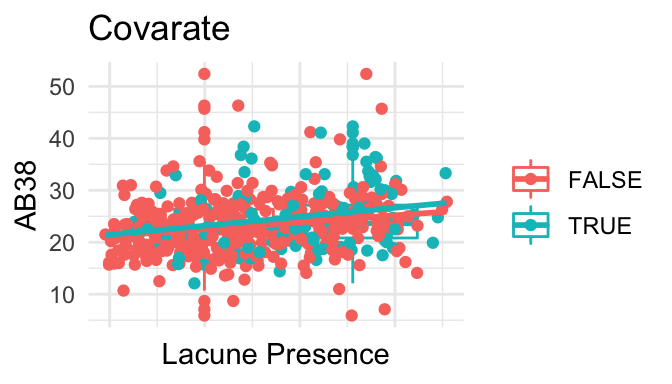

```r
ggplot(data, aes(y=AB38, x= age, color= lac_presence_b)) +
  geom_boxplot() +
  geom_point(position = position_jitter(width = 0.15, height = 0)) +
  geom_smooth(formula = y ~ x,method=lm, se=FALSE, fullrange=TRUE) +
  theme_minimal() +
  theme(axis.text.x = element_blank(), legend.title = element_blank()) +
  xlab("Lacune Presence") + ylab("AB38") + ggtitle("Covarate")
```